# Manipulating GPX tracks and points with sf and dplyr

Topics illustrated in this worked example:

- Read in data from files in the [GPS Exchange Format](https://en.wikipedia.org/wiki/GPS_Exchange_Format) (GPX).
- Convert measurement units with functions from the units library.

# Load libraries and read-in GPX-data

```r
library(leaflet)
library(dplyr)
library(sf)
library(lubridate)
library(ggplot2)
library(zoo)
library(cowplot)
library(scales)
```

Using `st_read()` from [the sf library](https://www.jessesadler.com/post/simple-feature-objects/), read in the GPX-file of a hike in Bryce Canyon National Park (clone the [Github repository](https://github.com/mhermans/rgeonotebooks), or [download the file directly](https://raw.githubusercontent.com/mhermans/rgeonotebooks/master/sf_track_manipulation/20180512_us_bryce_hike_11h50m36s.gpx)).

```r
bryce.track <- st_read("20180512_us_bryce_hike_11h50m36s.gpx", layer = "tracks")
bryce.trackpoints <- st_read("20180512_us_bryce_hike_11h50m36s.gpx", layer = "track_points")
```

Make an interactive map of the track and the trackpoints using [leaflet](https://rstudio.github.io/leaflet/):

[interactive chart not shown]

```r
leaflet(bryce.trackpoints) %>%
  addTiles() %>%
  addCircles()
```

[interactive chart not shown]

# Datacleaning: filter out the shuttle-transport

The tracked GPS-data unfortunately contain not only the Bryce NP hike, but also the shuttle transport to the trailhead. We want to filter that first part out, and work with the data of only the hike. To do so, we calculate the speed at each tracked point to determine the timestamp-cutoff after which the actual hike started.

First we get the pairwise distance and duration from the GPS-timestamps and coordinates. E.g. comparing the first point with the second, the second with the third, etc. A shorthand to do so, is droping for vector one the last value with `head(x, -1)` and for the second vector dropping the first value with `tail(x, -1)`. Comparing these two vectors and prepending a zero for the first point, gives us full vectors of distances and timedifferences.

```r
bryce.trackpoints %>%
  mutate(
    # convert the time string to a lubridate datetime object w/t proper timezone.
    timestamp = with_tz(ymd_hms(time), 'MST7MDT'),
    distance_pairwise = c(0, st_distance(head(geometry, -1), tail(geometry, -1), by_element = TRUE)),
    timediff_pairwise = c(0,difftime(tail(timestamp, -1), head(timestamp, -1))),
    speed = distance_pairwise / timediff_pairwise)
```

```
Simple feature collection with 1104 features and 31 fields
geometry type:  POINT
dimension:      XY
bbox:           xmin: -112.1737 ymin: 37.60708 xmax: -112.1575 ymax: 37.64017
epsg (SRID):    4326
proj4string:    +proj=longlat +datum=WGS84 +no_defs
First 10 features:
   track_fid track_seg_id track_seg_point_id  ele                time magvar geoidheight name  cmt desc  src link1_href link1_text link1_type link2_href
1          0            0                  0 2404 2018-05-12 19:50:38     NA          NA <NA> <NA> <NA> <NA>       <NA>       <NA>       <NA>       <NA>
2          0            0                  1 2389 2018-05-12 19:50:50     NA          NA <NA> <NA> <NA> <NA>       <NA>       <NA>       <NA>       <NA>
3          0            0                  2 2384 2018-05-12 19:50:59     NA          NA <NA> <NA> <NA> <NA>       <NA>       <NA>       <NA>       <NA>
4          0            0                  3 2380 2018-05-12 19:51:10     NA          NA <NA> <NA> <NA> <NA>       <NA>       <NA>       <NA>       <NA>
5          0            0                  4 2383 2018-05-12 19:51:22     NA          NA <NA> <NA> <NA> <NA>       <NA>       <NA>       <NA>       <NA>
6          0            0                  5 2376 2018-05-12 19:51:33     NA          NA <NA> <NA> <NA> <NA>       <NA>       <NA>       <NA>       <NA>
7          0            0                  6 2377 2018-05-12 19:51:39     NA          NA <NA> <NA> <NA> <NA>       <NA>       <NA>       <NA>       <NA>
```

[output cut: 25 more lines]

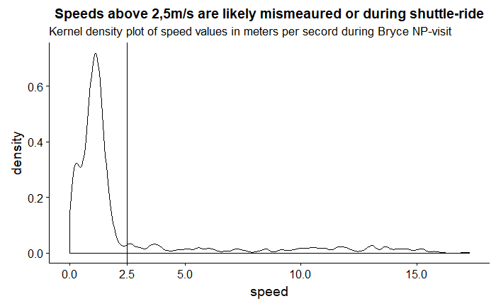

```r
ggplot(bryce.trackpoints, aes(x = speed)) + geom_density() +
  scale_x_continuous(breaks=c(0,2.5,5,10,15)) +
  geom_vline(xintercept = 2.5) + labs(
    title = 'Speeds above 2,5m/s are likely mismeaured or during shuttle-ride',
    subtitle = 'Kernel density plot of speed values in meters per secord during Bryce NP-visit')
```

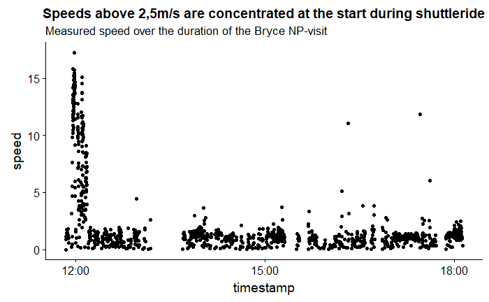

```r
p.speed <- ggplot(bryce.trackpoints, aes(x = timestamp, y = speed))
p.speed <- p.speed + geom_point()
p.speed + labs(
  title = 'Speeds above 2,5m/s are concentrated at the start during shuttleride',
  subtitle = 'Measured speed over the duration of the Bryce NP-visit')
```

```r
pal <- colorNumeric(
  palette = "RdYlGn",
  domain = bryce.trackpoints$speed,
  reverse = TRUE)
leaflet(bryce.trackpoints ) %>%
  addTiles() %>%
  addCircles(color = ~pal(speed))
```

[interactive chart not shown]

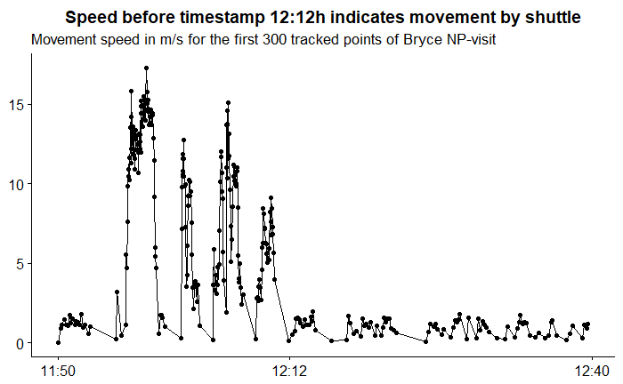

```r
p.speed %+% (bryce.trackpoints %>% slice(1:300)) +
  geom_line() + labs(
    x = NULL, y = NULL,
    title = 'Speed before timestamp 12:12h indicates movement by shuttle',
    subtitle = 'Movement speed in m/s for the first 300 tracked points of Bryce NP-visit') +
  scale_x_datetime(
    labels = date_format(format = '%H:%M', tz = 'MST7MDT'),
    breaks = c(
      min(bryce.trackpoints$timestamp),
      ymd_hms('2018-05-12 12:12:00', tz = 'MST7MDT'),
      ymd_hms('2018-05-12 12:40:00', tz = 'MST7MDT')))
```

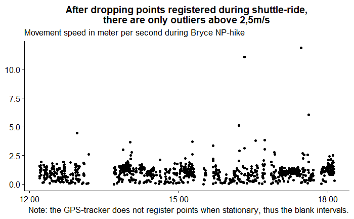

```r
timestamp_cutoff = ymd_hms('2018-05-12 12:12:00', tz = 'MST7MDT')
p.speed %+% (bryce.trackpoints %>% filter(timestamp> timestamp_cutoff)) +
  labs(
    x = NULL, y = NULL,
    title = 'After dropping points registered during shuttle-ride,\nthere are only outliers above 2,5m/s',
    subtitle = 'Movement speed in meter per second during Bryce NP-hike',
    caption = 'Note: the GPS-tracker does not register points when stationary, thus the blank intervals.')
```

```r
bryce.trackpoints.hike = bryce.trackpoints %>%
  filter(timestamp > timestamp_cutoff, speed < 2.5)
```

```r
pal <- colorNumeric(
  palette = "RdYlGn",
  domain = bryce.trackpoints.hike$speed,
  reverse = TRUE)
leaflet(bryce.trackpoints.hike) %>%
  addTiles() %>%
  addCircles(color = ~pal(speed))
```

[interactive chart not shown]

```r
bryce.trackpoints.hike <- bryce.trackpoints.hike %>%
  mutate(speed_rollmean = rollmean(speed, k = 3, align = 'center', fill = 'extend'))
```

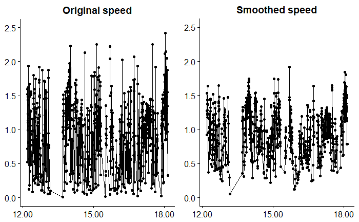

```r
p.speedcomparison <- ggplot(bryce.trackpoints.hike, aes(x = timestamp))
p1 <- p.speedcomparison + geom_point(aes(y = speed_rollmean)) + geom_line(aes(y = speed_rollmean)) + ylim(0, 2.5) + labs(title = 'Smoothed speed', x = NULL, y = NULL)
p2 <- p.speedcomparison + geom_point(aes(y = speed)) + geom_line(aes(y = speed)) + ylim(0, 2.5) + labs(title = 'Original speed', x = NULL, y = NULL)
plot_grid(p2, p1, align = 'v', axis = 'l')
```

```r
pal <- colorNumeric(
  palette = "RdYlGn",
  domain = bryce.trackpoints.hike$speed_rollmean,
  reverse = TRUE)
leaflet(bryce.trackpoints.hike) %>%
  addTiles() %>%
  addCircles(color = ~pal(speed_rollmean))
```

[interactive chart not shown]

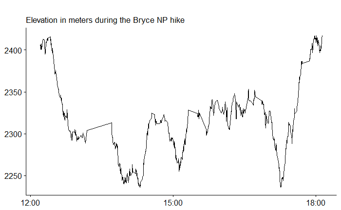

```r
p.elevation <- ggplot(bryce.trackpoints.hike, aes(x = timestamp, y =ele))
p.elevation + geom_line() + labs(x = NULL, y = NULL, title = '', subtitle = 'Elevation in meters during the Bryce NP hike')
```

```r
pal <- colorNumeric(
  palette = "RdYlGn",
  domain = bryce.trackpoints.hike$ele,
  reverse = TRUE)
leaflet(bryce.trackpoints.hike) %>%
  addTiles() %>%
  addCircles(color = ~pal(ele))
```

[interactive chart not shown]

```r
leaflet(bryce.trackpoints.hike) %>%
  addProviderTiles('OpenTopoMap') %>%
  addCircles(color = ~pal(ele))
```

[interactive chart not shown]

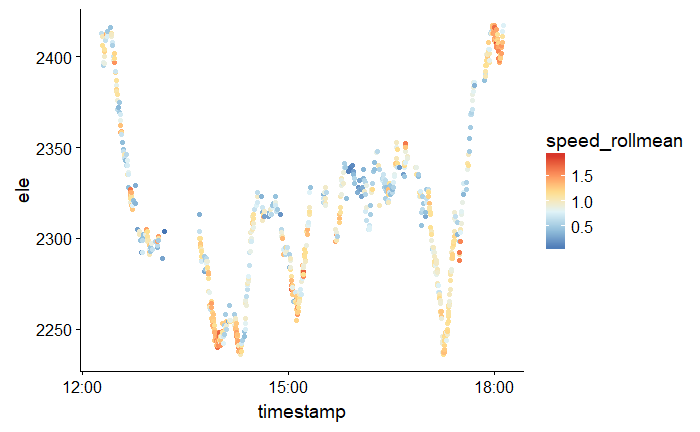

```r
p.elespeed <- ggplot(bryce.trackpoints.hike, aes(x = timestamp, y = ele, color = speed_rollmean))
p.elespeed + geom_point() + scale_colour_distiller(palette = 'RdYlBu')
```

```r
# bryce.track
bryce.track.hike = bryce.trackpoints.hike  %>%
  st_coordinates() %>%
  st_linestring() %>%
  st_sfc(crs = st_crs(bryce.track))
bryce.track.hike
```

```
Geometry set for 1 feature
geometry type:  LINESTRING
dimension:      XY
bbox:           xmin: -112.1666 ymin: 37.60708 xmax: -112.1575 ymax: 37.63097
epsg (SRID):    4326
proj4string:    +proj=longlat +datum=WGS84 +no_defs
```

```
LINESTRING (-112.1644 37.63097, -112.1643 37.63...
```

```r
leaflet(bryce.track.hike) %>%
  addTiles() %>%
  addPolylines()
```

[output not shown]

# Hiking distance, time and speed with units

With the cleaned linestring simple feature, we can get the distance hiked using `st_lenght()`. It returns the value with the unit of measurement, in this case meters. Rather than dividing by 1.000, we can do proper unit conversion using `set_units()` from the [units library](https://cran.r-project.org/web/packages/units/vignettes/measurement_units_in_R.html).

```r
st_length(bryce.track.hike)
```

```
10173.46 m
```

```r
hike.distance.total = set_units(st_length(bryce.track.hike), 'km')
hike.distance.total
```

[output not shown]

The base function `difftime()` gives us the time difference between the last and first timestamp of the hike, while `as_units()` converts it to a duration measurement-format compatible with the `units`-library.

```r
hike.time.total = as_units(difftime(
  max(bryce.trackpoints.hike$timestamp),
  min(bryce.trackpoints.hike$timestamp)))
hike.time.total
```

```
5.928333 h
```

```r
hike.distance.total / hike.time.total
```

```
1.716075 km/h
```

```r
set_units(hike.distance.total, 'm') / set_units(hike.time.total, 's')
```

[output not shown]